# Assignment 08: ATAC-seq exploration

Lukas Häuser

2024/05/02

```r
suppressPackageStartupMessages({
  library(epiwraps)
  library(motifmatchr)
  library(MotifDb)
  library(universalmotif)
  library(ggplot2)
  library(SummarizedExperiment) # data structure
  library(sechm) # for plotting heatmaps from a SummrizedExperiment
  library(BiocParallel) # for multithreading
  library(chromVAR) # for motif accessibility estimation
  library(limma) # for statistical analysis
})
```

```
## See system.file("LICENSE", package="MotifDb") for use restrictions.
```

```r
register(MulticoreParam(4))
```

# Motif Analysis

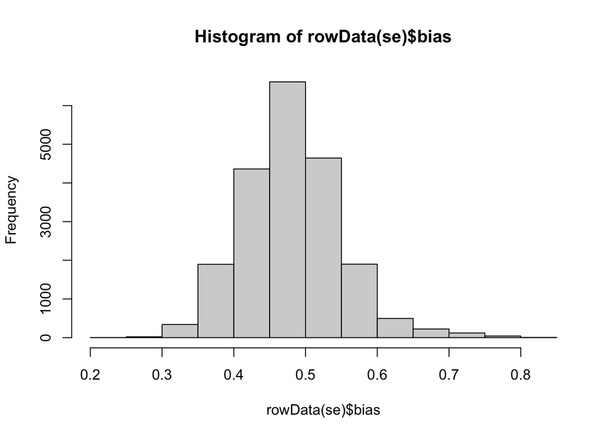

```r
# Setup data
se <- readRDS("mouse_mm38_hippocampus.peakCounts.SE.rds")
colData(se)$condition <- c("CTRL_FEMALE", "CTRL_FEMALE", "CTRL_FEMALE",
                           "CTRL_MALE", "CTRL_MALE", "CTRL_MALE",
                           "FSS_FEMALE", "FSS_FEMALE", "FSS_FEMALE",
                           "FSS_MALE", "FSS_MALE", "FSS_MALE")
rowRanges(se)$test <- 3
row.names(se) <- as.character(granges(se))

# Get mouse genome
genome <- Rsamtools::FaFile("Mus_musculus.GRCm38.dna.primary_assembly.fa2")

# Examine GC bias
se <- chromVAR::addGCBias(se, genome=genome)
hist(rowData(se)$bias)
```

```r
# Get motifs
motifs <- query(MotifDb, c("HOCOMOCOv10", "Mmusculus"))
motifs <- do.call(TFBSTools::PWMatrixList, setNames(
           universalmotif::convert_motifs(motifs, class="TFBSTools-PWMatrix"),
           mcols(motifs)$geneSymbol))

moi <- motifmatchr::matchMotifs(motifs, subject=se, genome=genome)

# Motif analysis
set.seed(0)
bg <- chromVAR::getBackgroundPeaks(se, niterations=1000)
dev <- chromVAR::computeDeviations(object = se, annotations=moi, background_peaks=bg)
```

# Differential analysis: CTRL vs. FSS

```r
# Setup model
dev$condition <- c("CTRL", "CTRL", "CTRL",
                   "CTRL", "CTRL", "CTRL",
                   "FSS", "FSS", "FSS",
                   "FSS", "FSS", "FSS")
dev$condition <- factor(dev$condition)
dev$condition <- relevel(dev$condition, "CTRL")
mm <- model.matrix(~dev$condition)
print(mm)
```

```
##    (Intercept) dev$conditionFSS
## 1            1                0
## 2            1                0
## 3            1                0
## 4            1                0
## 5            1                0
## 6            1                0
## 7            1                1
## 8            1                1
## 9            1                1
## 10           1                1
## 11           1                1
## 12           1                1
## attr(,"assign")
## [1] 0 1
## attr(,"contrasts")
## attr(,"contrasts")$`dev$condition`
## [1] "contr.treatment"
```

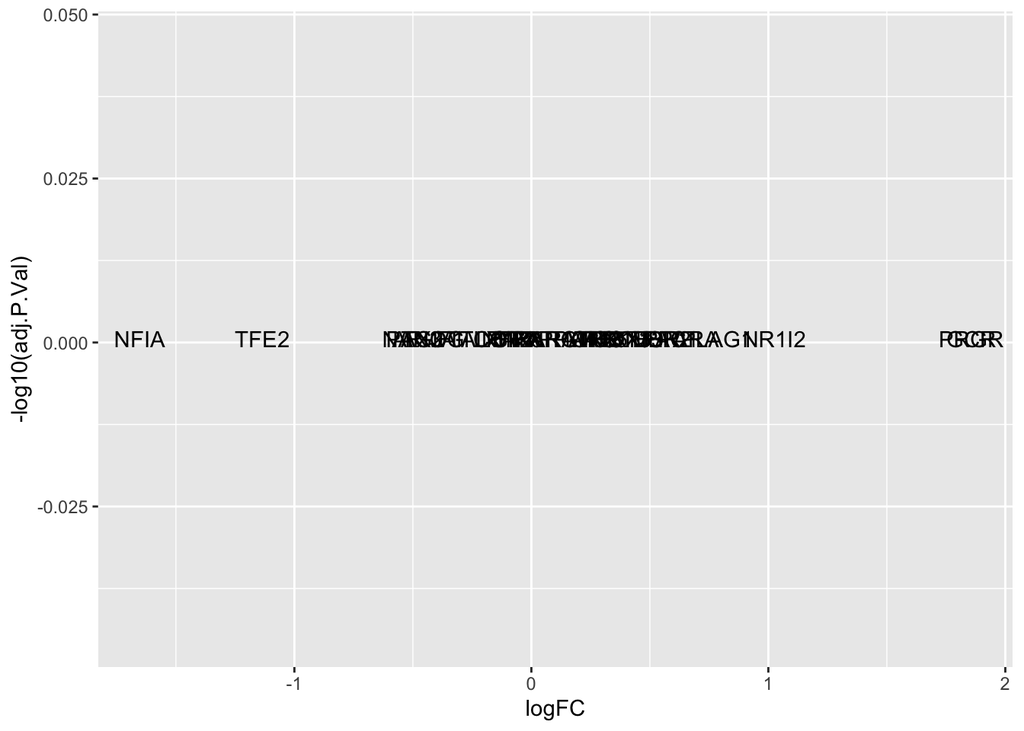

```r
# Fit model
fit <- limma::eBayes(limma::lmFit(object = assays(dev)$z, design = mm))
res <- as.data.frame(limma::topTable(fit, coef=2, number = Inf))
res$TF <- row.names(res)
res <- res[duplicated(res["ID"]),] # remove duplicates

# Vulcano plot
ggplot(res, aes(logFC, -log10(adj.P.Val), label=ID)) + geom_text()
```

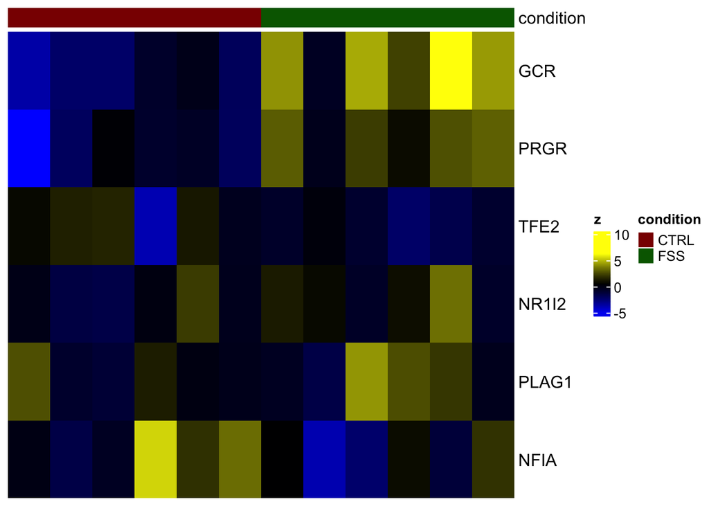

```r
# Heatmape of z scores
metadata(dev)$anno_colors <- list(condition=c(CTRL="darkred", FSS="darkgreen"))
row.names(res) <- res$ID
sechm::sechm(dev, features = head(row.names(res)), assayName="z")
```

```r
# Inspect most significant motifs
res[head(row.names(res)),]
```

```
##          ID      logFC     AveExpr          t   P.Value adj.P.Val         B  TF
## GCR     GCR  1.8564064  0.09628398  2.5943318 0.0210392 0.9988055 -3.352426 125
## PRGR   PRGR  1.8564064  0.09628398  2.5943318 0.0210392 0.9988055 -3.352426 308
## NFIA   NFIA -1.6528302  0.32303507 -1.4437635 0.1705321 0.9988055 -5.147486 236
## TFE2   TFE2 -1.1348270 -0.48909762 -1.2677901 0.2252931 0.9988055 -5.361881 390
## NR1I2 NR1I2  1.0253007  0.27739176  1.2266524 0.2399296 0.9988055 -5.408877 255
## PLAG1 PLAG1  0.7840984  0.68993216  0.7672022 0.4555448 0.9988055 -5.843302 291
```

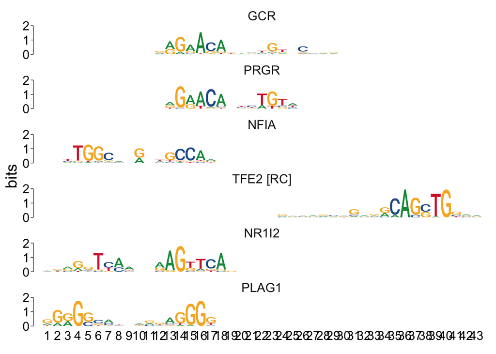

```r
view_motifs(motifs[head(row.names(res))])
```

The most significant motifs are GCR, PRGR, TFE2, NR1I2, PLAG1, and NFIA. The FSS condition results in a positive logFC of GCR and PRGR at about 1.9, while it is negative for NFIA and TFE2 at -1.7 and -1.1, respectively. Thus, the stress induces a higher expression of GCR and PRGR, and a lower expresstion of NFIA and TFE2. Further, the two most significant motifs GCR and PRGR are almost identical, which explains that they also have identical logFCs. The vulcano plot shows the same adjusted p values for all moifs. To me this looks more like an error, but I cannot explain it.

# Differential analysis: FEMALE vs. MALE

```r
# Setup model
dev$condition <- c("FEMALE", "FEMALE", "FEMALE",
                   "MALE", "MALE", "MALE",
                   "FEMALE", "FEMALE", "FEMALE",
                   "MALE", "MALE", "MALE")
dev$condition <- factor(dev$condition)
dev$condition <- relevel(dev$condition, "FEMALE")
mm <- model.matrix(~dev$condition)
print(mm)
```

```
##    (Intercept) dev$conditionMALE
## 1            1                 0
## 2            1                 0
## 3            1                 0
## 4            1                 1
## 5            1                 1
## 6            1                 1
## 7            1                 0
## 8            1                 0
## 9            1                 0
## 10           1                 1
## 11           1                 1
## 12           1                 1
## attr(,"assign")
## [1] 0 1
## attr(,"contrasts")
## attr(,"contrasts")$`dev$condition`
## [1] "contr.treatment"
```

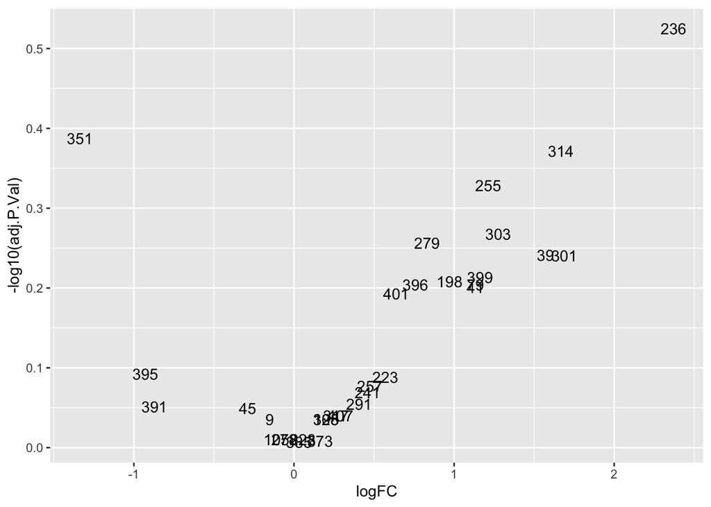

```r
# Fit model
fit <- limma::eBayes(limma::lmFit(object = assays(dev)$z, design = mm))
res <- as.data.frame(limma::topTable(fit, coef=2, number = Inf))
res$TF <- row.names(res)
res <- res[duplicated(res["ID"]),] # remove duplicates

# Vucano plot
ggplot(res, aes(logFC, -log10(adj.P.Val), label=TF)) + geom_text()
```

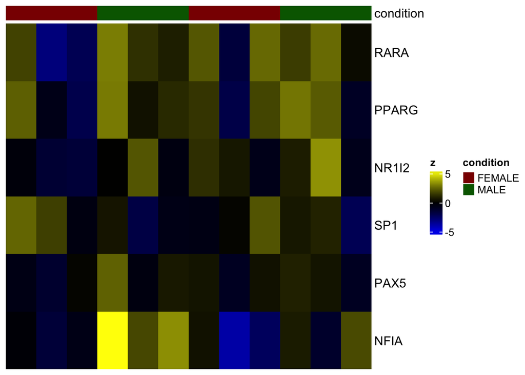

```r
# Heatmap of z scores
metadata(dev)$anno_colors <- list(condition=c(FEMALE="darkred", MALE="darkgreen"))
row.names(res) <- res$ID
sechm::sechm(dev, features = head(row.names(res)), assayName="z", breaks = 1)
```

```r
# Inspect most significant motifs
res[head(row.names(res)),]
```

```
##          ID      logFC   AveExpr         t    P.Value adj.P.Val         B  TF
## NFIA   NFIA  2.3711081 0.3230351  2.280365 0.03839078 0.2983674 -3.973489 236
## SP1     SP1 -1.3374591 0.2591827 -1.697048 0.11131785 0.4099275 -4.897289 351
## RARA   RARA  1.6671386 0.7934349  1.626580 0.12563495 0.4247658 -4.997709 314
## NR1I2 NR1I2  1.2137706 0.2773918  1.508655 0.15314239 0.4693429 -5.159216 255
## PPARG PPARG  1.2757033 0.8162373  1.322592 0.20671617 0.5402521 -5.395936 303
## PAX5   PAX5  0.8313058 0.1265972  1.290872 0.21721050 0.5540819 -5.433924 279
```

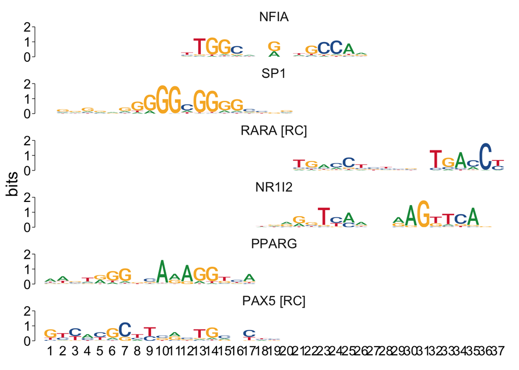

```r
view_motifs(motifs[head(row.names(res))])
```

Of the most significant motifs, all of their logFCs are positive, so they are more expressed in males compared to females; apart from SP1. From before, we know that stress decreases NFIA and increases NR1I2. Both these TFs are also strongly influenced by sex, where both are increased in males with respect to females.